# Day 17

## Review

**Sampling Distribution**

Given any population $Y \sim N(\mu,\sigma^2)$

Sample $X \sim N(\mu_X,\sigma^2_X)$

Sample mean $\bar{x} \sim N(\mu_{\bar{x}},\sigma^2_{\bar{x}})$

- Where: $\mu_{\bar{x}} = \mu$
- And: ${\sqrt{\sigma^2_{\bar{x}}}}=\sigma_{\bar{x}} = {\sigma \over \sqrt{n}}$

**Central Limit Theorem**

et $\bar{x}$ be the mean of a large random sample ($n > 30$) from *any* population

- With mean $\mu$ and standard deviation $\sigma$

The distribution of $\bar{x}$ is **approximately normal**

- Mean $\mu_{\bar{x}} = \mu$
- Standard deviation $\sigma_{\bar{x}} = \frac{\sigma}{\sqrt{n}}$

If $n$ is large enough, we have:

$$\bar{x} \sim N(\mu, \frac{\sigma^2}{n})$$

- **Regardless of the original population’s distribution**

> How large does $n$ need to be?

**Population Proportion**

Proportions are a useful way to interpret information about a population and sample without losing very much nuance at all:

- Proportions are just percentages of the population

Say the percentage of the population who participate in early voting is $40\%$

- ${40\over 100}=0.40$
- The proportion of the population who early vote, $p=0.40$

> If we poll a sample of 100 Manhattan residents and find that $31\%$ early vote:
- The proportion of our sample who early vote, $\hat{p}=0.31$

**Just like every other statistic, sample proportions are random variables**

- So their distribution is the **sampling distribution of the proportion**

**All of our previous rules and ideas apply**

- As we take samples from our population we will see they aren’t consistent
- The more we sample the closer we get to true values

Mean of the sample proportion $\hat{p}$ is:

$$\mu_{\hat{p}} = p \quad \text{(population proportion)}$$

Standard deviation of sample proportion $\hat{p}$ is:

$$\sigma_{\hat{p}} = \sqrt{\frac{p(1 - p)}{n}}$$

**Proportion Central Limit Theorem**

If $np \geq 10$ and $n(1 - p) \geq 10$

Distribution of $\hat{p}$ is *approximately normal*

- Mean $\mu_{\hat{p}} = p$
- Standard deviation $\sigma_{\hat{p}} = \sqrt{\frac{p(1 - p)}{n}}$

Thus:

$$\hat{p} \sim N \left( p, \frac{p(1 - p)}{n} \right)$$

**Point estimates** are a *deterministic* result

- Statistics deals with *probabilistic* results

It would be more informative to provide a **range of values**

**Questions?**

**Goals for today:**

1. Compute confidence intervals for point estimates arising from Normal data
2. Discuss interpretations of confidence intervals

## Sampling Distributions and Uncertainty I

### Confidence Intervals

> Since the value of $\bar{x}$ varies with each sample, we need to **quantify the uncertainty** associated with $\bar{x}$

> A random sample of $120$ students admitted to top business schools yielded an average GPA of $3.45$

$$\bar{x} = 3.45$$

This is a **point estimate** of $\mu$

- One number, no additional information provided

A **confidence interval** (CI) provides a range of values that contains:

1. The population parameter
2. A certain level of **confidence**, called the *confidence level*

**Formula for the CI:**

$$\text{Point estimate} \pm \text{Margin of Error}$$

The confidence interval for $\mu$:

$$\bar{x} \pm \text{Margin of Error}$$

$$(\bar{x} - \text{Margin of Error}, \bar{x} + \text{Margin of Error})$$

### Margin of error

> The farthest distance we believe our estimate $\bar{x}$ is from $\mu$

The size of the margin of error is determined by the **sampling distribution** of $\bar{x}$ and the **confidence level**

Confidence level is denoted by $100(1 - \alpha)\%$

- Typically $90\%$, $95\%$, or $99\%$

For a population with unknown $\mu$ but known $\sigma$, a $100(1 - \alpha)\%$ confidence interval for $\mu$ is computed as:

$$\bar{x} \pm z_{\alpha/2} \cdot \frac{\sigma}{\sqrt{n}}$$

Where $z_{\alpha/2}$ is the **z-score** with an area of $\alpha/2$ to its right

When construction a confidence interval for $\mu$

- We have to consider our **assumptions**

At least one of the following must hold:

1. The sample size is large ($n > 30$)
2. The original population is normally distributed

In most practical cases, $\sigma$ is unknown, and we must use the sample standard deviation $s$

The formula for the confidence interval is:

$$\bar{x} \pm t_{\alpha/2} \cdot \frac{s}{\sqrt{n}}$$

Where $t_{\alpha/2}$ is the **critical value** from the **Student’s t-distribution**, and $s$ is the sample standard deviation

### Student’s t-Distribution

The (Student’s) t-distribution is similar to the standard normal distribution

- Unimodal
- Symmetric around $0$

But it has *wider* (or heavier) **tails** than the standard normal

- Meaning it’s more spread out

The t-distribution is distinguished by **degrees of freedom** ($df = n - 1$)

- As $df$ increase the t-distribution converges to a normal distribution

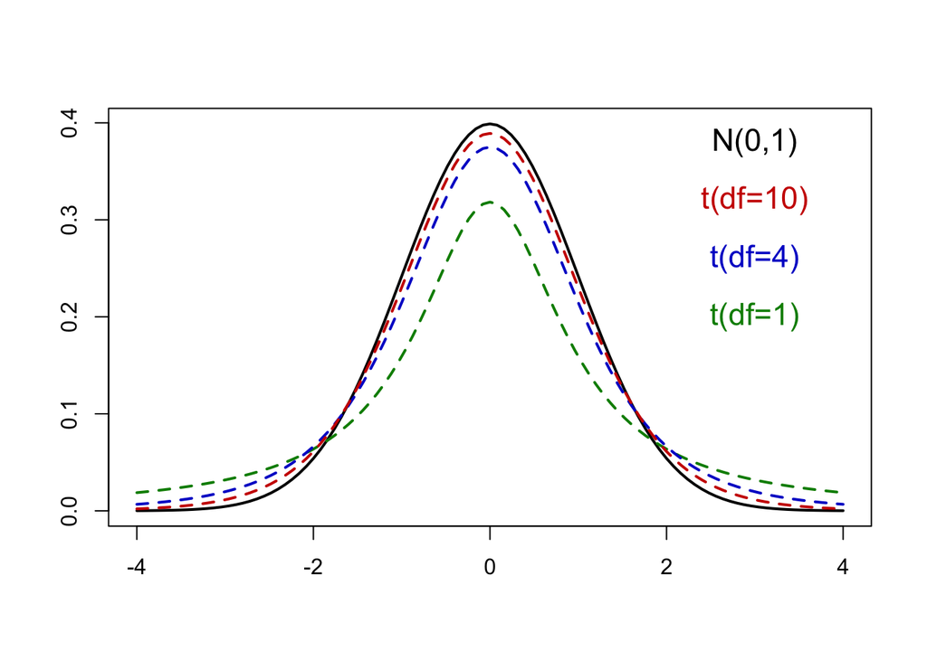

The **critical value** $t_{\alpha/2}$ is a $t$ value separating an area of $\alpha/2$ in the right tail of the $t$ distribution

When using the $t$ distribution ot construct a confidence interval for $\mu$:

- Degrees of freedom ($df$) is $1$ less than the *sample size*

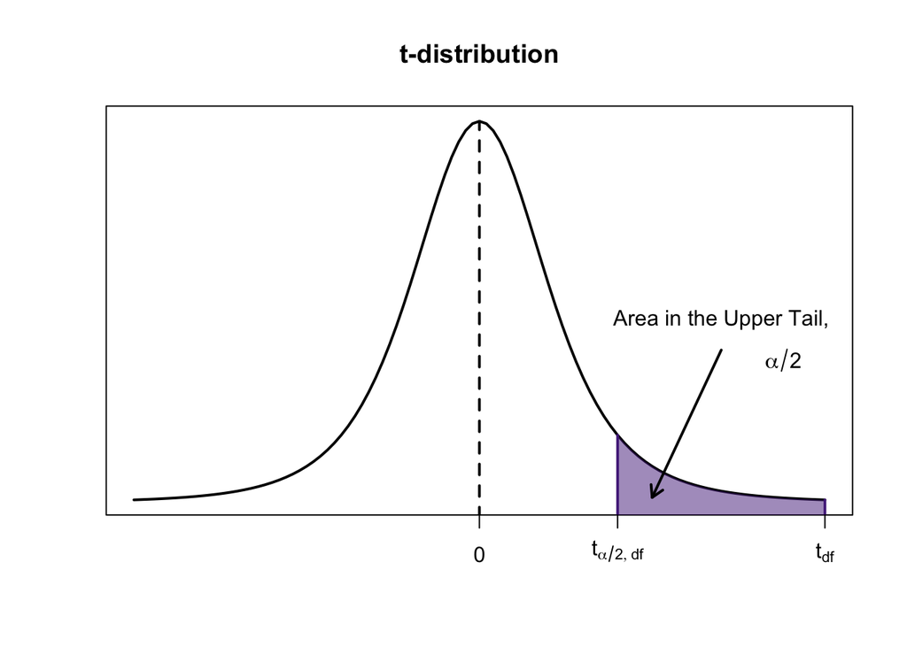

> Find the critical value $t_{\alpha/2}$ for a 95% confidence interval with $n = 8$
- Set $1 - \alpha = 0.95$, then $\alpha = 0.05$, and $\alpha/2 = 0.025$
- For $n = 8 \Rightarrow df = n-1 = 7$

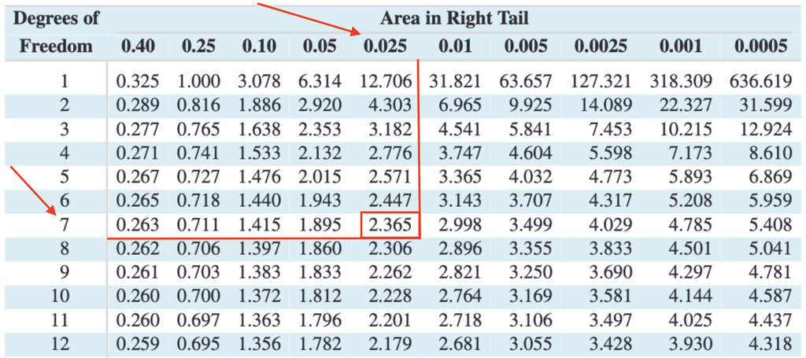

The critical value is $t_{\alpha/2} = 2.365$

> What if the $df$ I’m looking for isn’t in the table?

Round **down** to the nearest value on the table

- If $df=59$, round down to $df=50$
- At $95\%$ confidence, $t_{\alpha/2}=2.009$

Check your assumptions for construction a CI of $\mu$:

- Sample size is large ($n>30$) or the population is normal

$100(1-\alpha)\%$ confidence interval is computed as:

Case 1: $\sigma$ is known, use the z-method:

$$\bar{x} \pm z_{\alpha/2} \cdot \frac{\sigma}{\sqrt{n}}$$

Case 2: $\sigma$ is unknown, use the t-method:

$$\bar{x} \pm t_{\alpha/2} \cdot \frac{s}{\sqrt{n}}$$

> Given a sample of size $n = 5$ from a normal population, $\bar{x} = 4.31$, and $s = 2.7$, construct a 95% confidence interval for $\mu$
1. Should we use $z$ method or $t$ method?
- $\sigma$ is unknown
2. Compute the margin of error for this $95\%$ confidence interval:
- With $df = 4$ and $t_{\alpha/2} = 2.776$, calculate:

$$\text{Margin of Error} = 2.776 \times \frac{2.7}{\sqrt{5}} \approx 3.352$$

3. Construct a $95\%$ confidence interval for $\mu$ and interpret your result:

$$4.31 \pm 3.352 \quad \text{or} \quad (0.958, 7.662)$$

- We are 95% confident that the true population mean lies between 0.958 and 7.662
4. If the population were not normal, would the confidence interval in (c) be valid?

### Interpreting a CI

Suppose we take many random samples and construct a $95\%$ confidence interval from each sample

$95\%$ of those intervals would contain the true population mean, $\mu$

[figure not shown]

> In practice we say that we’re $95\%$ **confident** that the true value of $\mu$ is within our confidence interval